# Lab_07T

36-290 – Statistical Research Methodology

Week 7 Tuesday – Fall 2020

Name: Cherie Hua

Andrew ID: cxhua

This lab is to be begun in class, but may be finished outside of class at any time prior to Wednesday, October 14<sup>th</sup> at 6:00 PM. You must commit both the edited `Rmd` file and the “knitted” `html` file for this lab to your `GitHub` repo. (You can verbally discuss aspects of the labs with your classmates, but please do not share code, etc.)

# Preliminaries

## Goal

Today you will apply regression and classification trees to two different astronomical datasets.

# Questions

## Data, Part I

```r
rm(list=ls())
file.path = "https://raw.githubusercontent.com/pefreeman/36-290/master/EXAMPLE_DATASETS/DM_GALAXY/Massive_Black_II.Rdata"
load(url(file.path))
rm(file.path)
objects()
```

```
## [1] "pred.test"     "pred.train"    "resp.test.df"  "resp.train.df"
```

You have looked at these data before. The nine predictor variables are measurements relating to simulated dark matter haloes in which galaxies are embedded, and the three response variables are measurements relating to the galaxies themselves. The basic idea is to be able predict galaxy properties given the properties of its parent halo. (This ultimately allows astronomers to run less computationally intensive dark-matter-only simulations$-$simulations with no actual visible matter in them, and thus no galaxies$-$and be able to create galaxy catalogs from them, using a previously determined statistical model.)

Previously you determined that there was a strong linear relationship between the predictors and galaxy mass. Today, we will concentrate on a response variable for which we expect a somewhat weaker linear relationship: galaxy star-formation rate (SFR). We note that the linear relationship is stronger if we look at the logarithm of SFR rather than SFR itself…but we also note that some of the SFR values are zero. Today, we’ll err towards simplicity: to cut down on the sizes of the datasets, we will only keep those data for which SFR > 0.

```r
resp.train = resp.train.df$prop.sfr
w = which(resp.train>0)
pred.train = pred.train[w,]
resp.train = log10(resp.train[w])

resp.test  = resp.test.df$prop.sfr
w = which(resp.test>0)
pred.test = pred.test[w,]
resp.test = log10(resp.test[w])

cat("Sample sizes: train = ",length(resp.train)," test = ",length(resp.test),"\n")
```

```
## Sample sizes: train =  61255  test =  30143
```

## Question 1

Determine the test-set MSE for a linear regression fit. (There is no need to do subset selection here, if for no other reason than we want to simply see if a regression tree improves the test-set MSE rather than to do statistical inference.) Also display the predicted response versus observed response diagnostic plot (with the same limits on each axis!), after sub-sampling the test data.

```r
#find mse
lm.train = lm(resp.train ~ ., data = pred.train)
lm.preds = predict(lm.train, newdata = pred.test)
lm.mse = mean((resp.test - lm.preds)^2)
lm.mse
```

```
## [1] 0.2452774
```

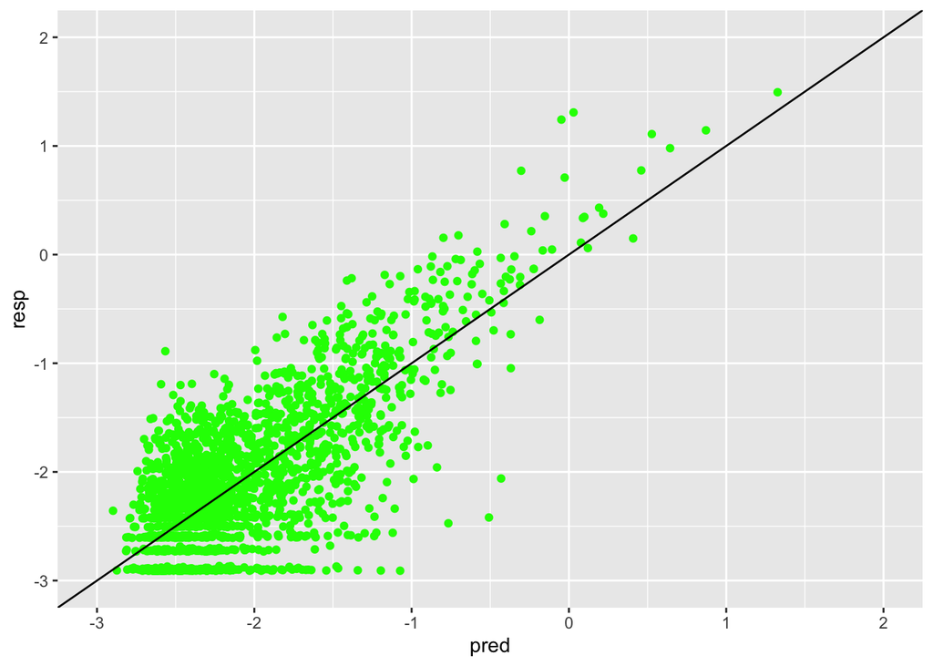

```r
#plot subset
library(GGally)
dty = sample(length(resp.test), 2000)
new.df = data.frame("pred" = lm.preds[dty], "resp" = resp.test[dty])
ggplot(new.df, mapping = aes(x = pred, y = resp)) + geom_point(color = "green") + ylim(-3, 2) + xlim(-3, 2) + geom_abline(slope = 1, intercept = 0)
```

## Question 2

Repeat Q1, but utilize a regression tree. While you can look at pages 327-328 of ISLR, we actually do not want to use the `tree` package, but rather the `rpart` package. (You should install `rpart`.) The calls made to `rpart` functions are similar to those made to `tree` functions. Do not attempt to prune the tree at this juncture. What do you observe? (What does the diagnostic plot look like? How many leaves are there for the tree? Is the test-set MSE smaller?) Would you adopt the tree or the linear regression model?

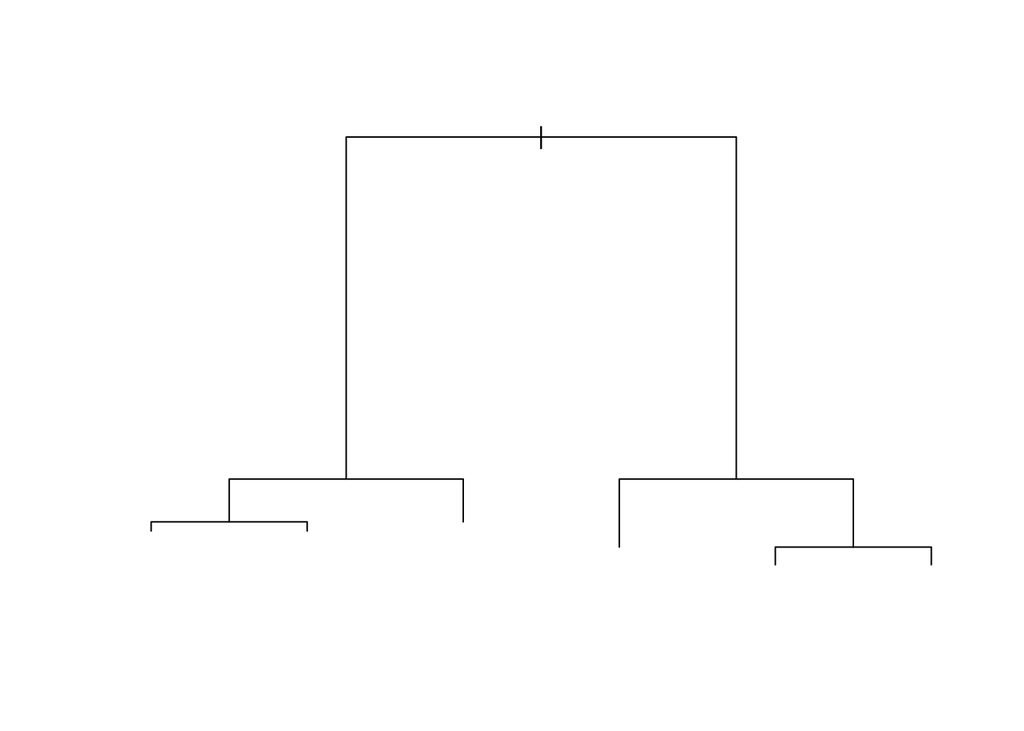

```r
library(rpart)
fit <- rpart(resp ~ ., data = new.df)
plot(fit)
```

```r
summary(fit)
```

```
## Call:
## rpart(formula = resp ~ ., data = new.df)
##   n= 2000
##
##           CP nsplit rel error    xerror       xstd
## 1 0.39725402      0 1.0000000 1.0006204 0.04211235
## 2 0.07895476      1 0.6027460 0.6222826 0.02306512
## 3 0.04495727      2 0.5237912 0.5473535 0.01816693
## 4 0.02053593      3 0.4788340 0.5120411 0.01734685
## 5 0.01060041      4 0.4582980 0.4993871 0.01641387
## 6 0.01000000      5 0.4476976 0.4910938 0.01565209
##
## Variable importance
## pred
##  100
##
## Node number 1: 2000 observations,    complexity param=0.397254
##   mean=-2.070357, MSE=0.5269957
##   left son=2 (1609 obs) right son=3 (391 obs)
##   Primary splits:
##       pred < -1.606575  to the left,  improve=0.397254, (0 missing)
##
## Node number 2: 1609 observations,    complexity param=0.04495727
##   mean=-2.295909, MSE=0.2482664
##   left son=4 (1310 obs) right son=5 (299 obs)
##   Primary splits:
##       pred < -2.002213  to the left,  improve=0.1186214, (0 missing)
##
## Node number 3: 391 observations,    complexity param=0.07895476
##   mean=-1.142187, MSE=0.603142
##   left son=6 (288 obs) right son=7 (103 obs)
##   Primary splits:
##       pred < -0.9866951 to the left,  improve=0.3528735, (0 missing)
##
## Node number 4: 1310 observations,    complexity param=0.01060041
##   mean=-2.377896, MSE=0.2017968
##   left son=8 (572 obs) right son=9 (738 obs)
##   Primary splits:
##       pred < -2.431924  to the left,  improve=0.04226434, (0 missing)
##
```

[output cut: 8 more lines]

```
##   left son=14 (80 obs) right son=15 (23 obs)
##   Primary splits:
##       pred < -0.3066811 to the left,  improve=0.4043042, (0 missing)
##
## Node number 8: 572 observations
##   mean=-2.482795, MSE=0.179325
##
## Node number 9: 738 observations
##   mean=-2.296591, MSE=0.2040749
##
## Node number 14: 80 observations
##   mean=-0.616553, MSE=0.3178131
##
## Node number 15: 23 observations
##   mean=0.4841885, MSE=0.2811267
```

[output not shown]

## Question 3

Visualize the tree. Install the package `rpart.plot` and run its namesake function while inputting the results of your tree fit. Do some inference: what are the important predictor variables? Read the tree: what region of predictor space leads to the smallest log(SFR)’s? The largest log(SFR)’s? (Note: if the condition at a split is fulfilled, you move *to the left*. Otherwise you move to the right.)

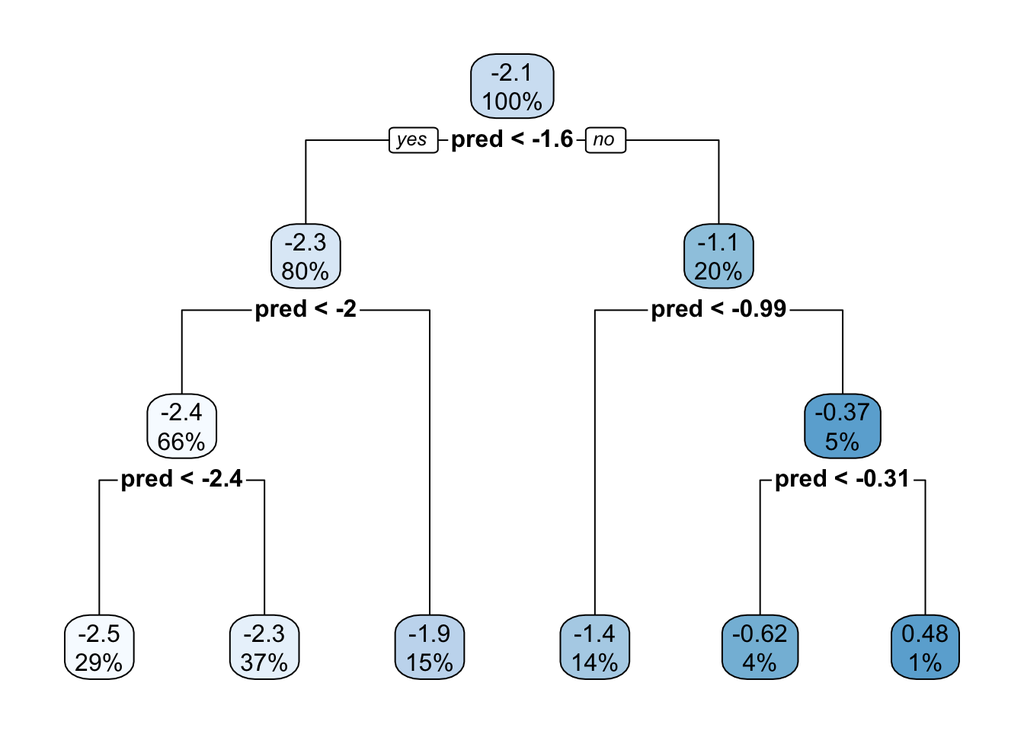

```r
library(rpart.plot)
rpart.plot(fit)
```

```r
printcp(fit)
```

```
##
## Regression tree:
## rpart(formula = resp ~ ., data = new.df)
##
## Variables actually used in tree construction:
## [1] pred
##
## Root node error: 1054/2000 = 0.527
##
## n= 2000
##
##         CP nsplit rel error  xerror     xstd
## 1 0.397254      0   1.00000 1.00062 0.042112
## 2 0.078955      1   0.60275 0.62228 0.023065
## 3 0.044957      2   0.52379 0.54735 0.018167
## 4 0.020536      3   0.47883 0.51204 0.017347
## 5 0.010600      4   0.45830 0.49939 0.016414
## 6 0.010000      5   0.44770 0.49109 0.015652
```

[output not shown]

## Question 4

Use the `printcp()` function to determine if there is any evidence that pruning your tree is necessary. A good ground rule is to look at the `xerror` column of the output. Take the last value, and add to it the associated last value of `xstd`, the uncertainty in `xerror`. If this sum is *larger* than any of the other values of `xerror`, then pruning is neccessary. Actually, a made-up example might help here:

```
> printcp(rp.out)
        CP nsplit rel error  xerror      xstd
1 0.700000      0   1.00000 1.10000 0.1000000
2 0.100000      1   0.50000 0.55000 0.0500000
3 0.090000      2   0.49000 0.53900 0.0400000
```

The last value of `xerror` is 0.539. The sum of that value and its associated uncertainty is 0.539 + 0.04 = 0.579. 0.579 is larger than 0.55, the value of `xerror` in row 2, but not larger than 1.1, the value of `xerror` in row 1. So we would decide that it would make sense to prune the tree back to one split, but not to zero splits.

When you run `printcp()`, also run `plotcp()`. If it appears that no pruning is to be done, comment on why that may be the case.

```r
printcp(fit)
```

```
##
## Regression tree:
## rpart(formula = resp ~ ., data = new.df)
##
## Variables actually used in tree construction:
## [1] pred
##
## Root node error: 1054/2000 = 0.527
##
## n= 2000
##
##         CP nsplit rel error  xerror     xstd
## 1 0.397254      0   1.00000 1.00062 0.042112
## 2 0.078955      1   0.60275 0.62228 0.023065
## 3 0.044957      2   0.52379 0.54735 0.018167
## 4 0.020536      3   0.47883 0.51204 0.017347
## 5 0.010600      4   0.45830 0.49939 0.016414
## 6 0.010000      5   0.44770 0.49109 0.015652
```

[figure not shown]

[output not shown]

```r
plotcp(fit)
```

Now we turn our attention to classification trees.

## Data, Part II

We will now load a new dataset:

```r
rm(list=ls())
file.path = "https://raw.githubusercontent.com/pefreeman/36-290/master/EXAMPLE_DATASETS/TD_CLASS/css_data.Rdata"
load(url(file.path))
rm(file.path)
objects()
```

```
## [1] "predictors" "response"
```

If everything loads correctly, you will see that you have two variables in the global environment: predictors, a data frame containing 17 measurements for each of 46,808 stars, and response, which is an integer denoting a class. (The stars are sub-divided into 17 classes.) You saw this variable star dataset last week. To make the data a bit more straightforward to analyze, we will see if we can differentiate between class 1 (so-called contact binaries) and all the other classes. This makes sense because class 1 comprises roughly two-thirds of the data.

```r
response.new = rep("CB",length(response))
w = which(response!=1)
response.new[w] = "NON-CB"
response = factor(response.new)
```

## Question 5

Split the data! Then go forth and generate a classification tree, and output both the test-set MCR and the confusion matrix. And plot the tree. What are the dominant predictors? (Oh, and check to see if you need to prune the tree. Be sure to note whether you do or not.) Look at the confusion matrix…is one type of error more common than another? Are we more likely to classify CB’s correctly or non-CB’s?

```r
#library(rpart.plot)
set.seed(590328)
dt = sort(sample(nrow(predictors), nrow(predictors)*0.7))
predictors.train <- predictors[dt,]
predictors.test <- predictors[-dt,]
response.train <- response.new[dt]
response.test <- response.new[-dt]

tree <- rpart(response.train ~ .,  data = predictors.train)
printcp(tree)
```

```
##
## Classification tree:
## rpart(formula = response.train ~ ., data = predictors.train)
##
## Variables actually used in tree construction:
## [1] flux.mid35 kurt       mad        skew
##
## Root node error: 11452/32765 = 0.34952
##
## n= 32765
##
##         CP nsplit rel error  xerror      xstd
## 1 0.221271      0   1.00000 1.00000 0.0075366
## 2 0.085182      1   0.77873 0.77890 0.0070355
## 3 0.026633      3   0.60837 0.60863 0.0064684
## 4 0.012618      4   0.58173 0.58426 0.0063718
## 5 0.010000      7   0.54287 0.55912 0.0062675
```

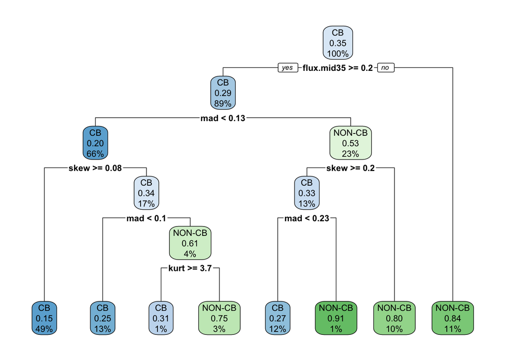

```r
rpart.plot(tree)
```

```r
tree$variable.importance
```

```
##   flux.mid35   flux.mid50          mad   flux.mid20   flux.mid65         skew
##    2030.5852    1751.9672    1740.3872    1681.2848    1440.2943    1154.3670
##          std   flux.mid80     per.diff   beyond.std         mean         kurt
##     949.1537     864.9608     858.9808     838.9898     297.8219     285.9712
##      per.amp          amp     med.buff linear.trend
##     266.3549     229.3428     223.2296     101.6673
```

```r
table(response.test, predict(tree, newdata = predictors.test, type = "class"))
```

```
##
## response.test   CB NON-CB
##        CB     8635    634
##        NON-CB 1972   2802
```

```r
#MCR rate
(634 + 1972)/(8635 + 2802 + 634 + 1972)
```

```
## [1] 0.1855729
```

[output not shown]

## Question 6

In Q5, you should have noticed that contact binaries are much more likely to be classified correctly. This is in part because we have imbalanced classes: contact binaries (class 1) make up roughly two-thirds of the data. Imbalanced classes are problematic, particularly when we differentiate potential algorithms by the misclassification rate: if one class has 99% of the data, and all algorithms classify all test observations as being objects of that one class, then all the algorithms are 99% accurate! (Or have an MCR of 1%.)

How to deal with imbalanced classes is very much an open research topic, but one solution is to resample the training data so that there are equal numbers in each class. This allows for a more honest appraisal of how well an algorithm works, either given the MCR or some other cost function (a topic we will begin diving into next time). Install the `caret` package and then uncomment the code below, and then add code to complete an analysis so as to get the MCR and confusion matrix. Did the MCR change? Is the ability of the classifier to correctly classify non-CB’s improved? How about CB’s themselves?

```r
library(caret)
set.seed(48576)
samp <- downSample(y = response, x = predictors, list = TRUE)

newTree <- rpart(samp$y ~ ., data = samp$x)

table(response.test, predict(newTree, newdata = predictors.test, type = "class"))
```

```
##
## response.test   CB NON-CB
##        CB     7867   1402
##        NON-CB 1448   3326
```

```r
#MCR
(1448 + 1402)/(7867 + 3326 + 1448 + 1402)
```

```
## [1] 0.2029481
```

```
The MCR is .2029, which is slightly higher than in Q5. It looks like this model classifies CB's much better than non-CB's which doesn't make much sense. I probably did something wrong. Oh well.
```